# 03_07_2023

ARQUE Maxime

2023-07-03

```r
library(panstripe)
library(ape)
library(patchwork)
library(TreeTools)
library(ggtree)
library(castor)
library(ggplot2)
library(phytools)
library(rpart)
library(tidyr)
library(tibble)
library(dplyr)
library(reshape2)
library(ggpmisc)
set.seed(1234)
```

# Suite : formation du tableau pour analyses statistiques

# Partie 1 Récupération de certaines données pour le tableau

## Importation des données 18 SAGS

```r
data_compartiments=read.csv("/home/maarque/Donnees_projet/Data/ALL_SAGS_genrefs/Annot_All_COGS.tsv", header=F, sep="\t", check.names = F)
colnames(data_compartiments)=c("COG","multi/single","gentype","shared","compartiment")


raw_data_18=read.csv("/home/maarque/Donnees_projet/Data/SAGs_reduits/Data_count/Count_BASH/family.txt", header=T, sep="\t", check.names = F)
raw_data_18=raw_data_18[!(apply(raw_data_18[, 3:(ncol(raw_data_18)-4)], 1, function(x) all(x == 0))), ]

data_count=raw_data_18[,c("name","Gains","Losses")]
colnames(data_count)[1]="COG"

data_merge_spec=merge(data_count,data_compartiments, by.x="COG", all = FALSE)
data_merge_spec_18=cbind(data_merge_spec,All_events=data_merge_spec$Gains+data_merge_spec$Losses)
data_merge_spec_18=subset(data_merge_spec_18, !grepl("comp|Ambiguous", compartiment) & grepl("",compartiment))

rm(data_compartiments)
rm(data_count)
```

## Importation des données 7 Genrefs

```r
data_compartiments=read.csv("/home/maarque/Donnees_projet/Data/ALL_SAGS_genrefs/Annot_All_COGS.tsv", header=F, sep="\t", check.names = F)
colnames(data_compartiments)=c("COG","multi/single","gentype","shared","compartiment")


raw_data_7=read.csv("/home/maarque/Donnees_projet/Data/7_Genrefs/COUNT_bash/family.txt", header=T, sep="\t", check.names = F)
raw_data_7=raw_data_7[!(apply(raw_data_7[, 3:(ncol(raw_data_7)-4)], 1, function(x) all(x == 0))), ]


data_count=raw_data_7[,c("name","Gains","Losses")]
colnames(data_count)[1]="COG"

data_merge_spec=merge(data_count,data_compartiments, by.x="COG", all = FALSE)
data_merge_spec_7=cbind(data_merge_spec,All_events=data_merge_spec$Gains+data_merge_spec$Losses)
data_merge_spec_7=subset(data_merge_spec_7, !grepl("comp|Ambiguous", compartiment) & grepl("",compartiment))


rm(data_compartiments)
rm(data_count)
```

## Importation des données 25 SAGS + Genrefs

```r
data_compartiments=read.csv("/home/maarque/Donnees_projet/Data/ALL_SAGS_genrefs/Annot_All_COGS.tsv", header=F, sep="\t", check.names = F)
colnames(data_compartiments)=c("COG","multi/single","gentype","shared","compartiment")


raw_data_25=read.csv("/home/maarque/Donnees_projet/Data/7_Genrefs_18_SAGS/COUNT_bash/family.txt", header=T, sep="\t", check.names = F)
raw_data_25=raw_data_25[!(apply(raw_data_25[, 3:(ncol(raw_data_25)-4)], 1, function(x) all(x == 0))), ]

data_count=raw_data_25[,c("name","Gains","Losses")]
colnames(data_count)[1]="COG"

data_merge_spec=merge(data_count,data_compartiments, by.x="COG", all = FALSE)
data_merge_spec_25=cbind(data_merge_spec,All_events=data_merge_spec$Gains+data_merge_spec$Losses)
data_merge_spec_25=subset(data_merge_spec_25, !grepl("comp|Ambiguous", compartiment) & grepl("",compartiment))


rm(data_compartiments)
rm(data_count)
rm(data_merge_spec)
```

# Partie 2 : Formation du tableau récapitulatif pour test statistiques

## Colnames

```r
Nom_col=c("Dataset","Gentype","Compartiment","COGS_per_compart","COGS_per_I_compart","COGS_wGain","COGS_wLoss","COGS_wGain&Loss","All_events_per_compart","All_gains","All_losses","Average_events_per_I_COGS","Average_gains_per_COGS","Average_losses_per_COGS","ET_average_events")

my_df=setNames(data.frame(matrix(ncol = 15, nrow = 36)), Nom_col)
my_df[,1][1:12]="18"
my_df[,1][13:24]="7"
my_df[,1][25:36]="25"
my_df[,2]=c(rep("core",6),rep("flex",6))
my_df[,3]=c("backbone","ISL1","ISL2","ISL3","ISL4","ISL5")
```

## COGS per compart

```r
SAG_core=table(data_merge_spec_18$compartiment[data_merge_spec_18$gentype=="core"])
GENREF_core=table(data_merge_spec_7$compartiment[data_merge_spec_7$gentype=="core"])
ALL_core=table(data_merge_spec_25$compartiment[data_merge_spec_25$gentype=="core"])

SAG_flex=table(data_merge_spec_18$compartiment[data_merge_spec_18$gentype=="flex"])
GENREF_flex=table(data_merge_spec_7$compartiment[data_merge_spec_7$gentype=="flex"])
ALL_flex=table(data_merge_spec_25$compartiment[data_merge_spec_25$gentype=="flex"])

my_df[,4][1:6]=SAG_core
my_df[,4][7:12]=SAG_flex

my_df[,4][13:18]=GENREF_core
my_df[,4][19:24]=GENREF_flex

my_df[,4][25:30]=ALL_core
my_df[,4][31:36]=ALL_flex
```

## COGS per impacted compart

```r
SAG_core=table(data_merge_spec_18$compartiment[data_merge_spec_18$gentype=="core" & data_merge_spec_18$All_events>=1])
GENREF_core=table(data_merge_spec_7$compartiment[data_merge_spec_7$gentype=="core" & data_merge_spec_7$All_events>=1])
ALL_core=table(data_merge_spec_25$compartiment[data_merge_spec_25$gentype=="core" & data_merge_spec_25$All_events>=1])

SAG_flex=table(data_merge_spec_18$compartiment[data_merge_spec_18$gentype=="flex" & data_merge_spec_18$All_events>=1])
GENREF_flex=table(data_merge_spec_7$compartiment[data_merge_spec_7$gentype=="flex" & data_merge_spec_7$All_events>=1])
ALL_flex=table(data_merge_spec_25$compartiment[data_merge_spec_25$gentype=="flex" & data_merge_spec_25$All_events>=1])

my_df[,5][1:6]=SAG_core
my_df[,5][7:12]=SAG_flex

my_df[,5][13:18]=GENREF_core
my_df[,5][19:24]=GENREF_flex

my_df[,5][25:30]=ALL_core
my_df[,5][31:36]=ALL_flex
```

## COGS with gains

```r
SAG_core=table(data_merge_spec_18$compartiment[data_merge_spec_18$gentype=="core" & data_merge_spec_18$Gains>=1])
SAG_core=c(SAG_core,c(ISL1=0, ISL2=0))
SAG_core=SAG_core[c("Backbone","ISL1","ISL2","ISL3","ISL4","ISL5")]

GENREF_core=table(data_merge_spec_7$compartiment[data_merge_spec_7$gentype=="core" & data_merge_spec_7$Gains>=1])
GENREF_core=c(GENREF_core,c(ISL1=0, ISL4=0))
GENREF_core=GENREF_core[c("Backbone","ISL1","ISL2","ISL3","ISL4","ISL5")]


ALL_core=table(data_merge_spec_25$compartiment[data_merge_spec_25$gentype=="core" & data_merge_spec_25$Gains>=1])
ALL_core=c(ALL_core,c(ISL1=0, ISL4=0))
ALL_core=ALL_core[c("Backbone","ISL1","ISL2","ISL3","ISL4","ISL5")]



SAG_flex=table(data_merge_spec_18$compartiment[data_merge_spec_18$gentype=="flex" & data_merge_spec_18$Gains>=1])
GENREF_flex=table(data_merge_spec_7$compartiment[data_merge_spec_7$gentype=="flex" & data_merge_spec_7$Gains>=1])
ALL_flex=table(data_merge_spec_25$compartiment[data_merge_spec_25$gentype=="flex" & data_merge_spec_25$Gains>=1])

my_df[,6][1:6]=SAG_core
my_df[,6][7:12]=SAG_flex

my_df[,6][13:18]=GENREF_core
my_df[,6][19:24]=GENREF_flex

my_df[,6][25:30]=ALL_core
my_df[,6][31:36]=ALL_flex
```

## COGS with losses

```r
SAG_core=table(data_merge_spec_18$compartiment[data_merge_spec_18$gentype=="core" & data_merge_spec_18$Losses>=1])
GENREF_core=table(data_merge_spec_7$compartiment[data_merge_spec_7$gentype=="core" & data_merge_spec_7$Losses>=1])
ALL_core=table(data_merge_spec_25$compartiment[data_merge_spec_25$gentype=="core" & data_merge_spec_25$Losses>=1])

SAG_flex=table(data_merge_spec_18$compartiment[data_merge_spec_18$gentype=="flex" & data_merge_spec_18$Losses>=1])
GENREF_flex=table(data_merge_spec_7$compartiment[data_merge_spec_7$gentype=="flex" & data_merge_spec_7$Losses>=1])
ALL_flex=table(data_merge_spec_25$compartiment[data_merge_spec_25$gentype=="flex" & data_merge_spec_25$Losses>=1])

my_df[,7][1:6]=SAG_core
my_df[,7][7:12]=SAG_flex

my_df[,7][13:18]=GENREF_core
my_df[,7][19:24]=GENREF_flex

my_df[,7][25:30]=ALL_core
my_df[,7][31:36]=ALL_flex
```

## COGS with gains & losses

```r
SAG_core=table(data_merge_spec_18$compartiment[data_merge_spec_18$gentype=="core" & data_merge_spec_18$Losses>=1 & data_merge_spec_18$Gains>=1])
SAG_core=c(SAG_core,c(ISL1=0, ISL2=0))
SAG_core=SAG_core[c("Backbone","ISL1","ISL2","ISL3","ISL4","ISL5")]

GENREF_core=table(data_merge_spec_7$compartiment[data_merge_spec_7$gentype=="core" & data_merge_spec_7$Losses>=1 & data_merge_spec_7$Gains>=1])
GENREF_core=c(GENREF_core,c(ISL1=0, ISL2=0, ISL3=0, ISL4=0, ISL5=0))
GENREF_core=GENREF_core[c("Backbone","ISL1","ISL2","ISL3","ISL4","ISL5")]

ALL_core=table(data_merge_spec_25$compartiment[data_merge_spec_25$gentype=="core" & data_merge_spec_25$Losses>=1 & data_merge_spec_25$Gains>=1])
ALL_core=c(ALL_core,c(ISL1=0, ISL2=0, ISL3=0, ISL4=0))
ALL_core=ALL_core[c("Backbone","ISL1","ISL2","ISL3","ISL4","ISL5")]



SAG_flex=table(data_merge_spec_18$compartiment[data_merge_spec_18$gentype=="flex" & data_merge_spec_18$Losses>=1 & data_merge_spec_18$Gains>=1])

GENREF_flex=table(data_merge_spec_7$compartiment[data_merge_spec_7$gentype=="flex" & data_merge_spec_7$Losses>=1 & data_merge_spec_7$Gains>=1])
GENREF_flex=c(GENREF_flex,c(ISL1=0, ISL3=0, ISL4=0))
GENREF_flex=GENREF_flex[c("Backbone","ISL1","ISL2","ISL3","ISL4","ISL5")]

ALL_flex=table(data_merge_spec_25$compartiment[data_merge_spec_25$gentype=="flex" & data_merge_spec_25$Losses>=1 & data_merge_spec_25$Gains>=1])
ALL_flex=c(ALL_flex,c(ISL2=0))
ALL_flex=ALL_flex[c("Backbone","ISL1","ISL2","ISL3","ISL4","ISL5")]

my_df[,8][1:6]=SAG_core
my_df[,8][7:12]=SAG_flex

my_df[,8][13:18]=GENREF_core
my_df[,8][19:24]=GENREF_flex

my_df[,8][25:30]=ALL_core
my_df[,8][31:36]=ALL_flex
```

## All events per compart

```r
SAG_core1=aggregate(Gains ~ compartiment, data = data_merge_spec_18, FUN = sum, subset = gentype == "core" & Losses >= 0 & Gains >= 0)
SAG_core2=aggregate(Losses ~ compartiment, data = data_merge_spec_18, FUN = sum, subset = gentype == "core" & Losses >= 0 & Gains >= 0)
SAG_core=SAG_core1$Gains+SAG_core2$Losses

GENREF_core1=aggregate(Gains ~ compartiment, data = data_merge_spec_7, FUN = sum, subset = gentype == "core" & Losses >= 0 & Gains >= 0)
GENREF_core2=aggregate(Losses ~ compartiment, data = data_merge_spec_7, FUN = sum, subset = gentype == "core" & Losses >= 0 & Gains >= 0)
GENREF_core=GENREF_core1$Gains+GENREF_core2$Losses

ALL_core1=aggregate(Gains ~ compartiment, data = data_merge_spec_25, FUN = sum, subset = gentype == "core" & Losses >= 0 & Gains >= 0)
ALL_core2=aggregate(Losses ~ compartiment, data = data_merge_spec_25, FUN = sum, subset = gentype == "core" & Losses >= 0 & Gains >= 0)
ALL_core=ALL_core1$Gains+ALL_core2$Losses



SAG_flex1=aggregate(Gains ~ compartiment, data = data_merge_spec_18, FUN = sum, subset = gentype == "flex" & Losses >= 0 & Gains >= 0)
SAG_flex2=aggregate(Losses ~ compartiment, data = data_merge_spec_18, FUN = sum, subset = gentype == "flex" & Losses >= 0 & Gains >= 0)
SAG_flex=SAG_flex1$Gains+SAG_flex2$Losses

GENREF_flex1=aggregate(Gains ~ compartiment, data = data_merge_spec_7, FUN = sum, subset = gentype == "flex" & Losses >= 0 & Gains >= 0)
GENREF_flex2=aggregate(Losses ~ compartiment, data = data_merge_spec_7, FUN = sum, subset = gentype == "flex" & Losses >= 0 & Gains >= 0)
GENREF_flex=GENREF_flex1$Gains+GENREF_flex2$Losses

ALL_flex1=aggregate(Gains ~ compartiment, data = data_merge_spec_25, FUN = sum, subset = gentype == "flex" & Losses >= 0 & Gains >= 0)
ALL_flex2=aggregate(Losses ~ compartiment, data = data_merge_spec_25, FUN = sum, subset = gentype == "flex" & Losses >= 0 & Gains >= 0)
ALL_flex=ALL_flex1$Gains+ALL_flex2$Losses



my_df[,9][1:6]=SAG_core
my_df[,9][7:12]=SAG_flex

my_df[,9][13:18]=GENREF_core
my_df[,9][19:24]=GENREF_flex

my_df[,9][25:30]=ALL_core
my_df[,9][31:36]=ALL_flex
```

## All_gains

```r
SAG_core1=aggregate(Gains ~ compartiment, data = data_merge_spec_18, FUN = sum, subset = gentype == "core" & Losses >= 0 & Gains >= 0)
SAG_core=SAG_core1$Gains

GENREF_core1=aggregate(Gains ~ compartiment, data = data_merge_spec_7, FUN = sum, subset = gentype == "core" & Losses >= 0 & Gains >= 0)
GENREF_core=GENREF_core1$Gains

ALL_core1=aggregate(Gains ~ compartiment, data = data_merge_spec_25, FUN = sum, subset = gentype == "core" & Losses >= 0 & Gains >= 0)
ALL_core=ALL_core1$Gains



SAG_flex1=aggregate(Gains ~ compartiment, data = data_merge_spec_18, FUN = sum, subset = gentype == "flex" & Losses >= 0 & Gains >= 0)
SAG_flex=SAG_flex1$Gains

GENREF_flex1=aggregate(Gains ~ compartiment, data = data_merge_spec_7, FUN = sum, subset = gentype == "flex" & Losses >= 0 & Gains >= 0)
GENREF_flex=GENREF_flex1$Gains

ALL_flex1=aggregate(Gains ~ compartiment, data = data_merge_spec_25, FUN = sum, subset = gentype == "flex" & Losses >= 0 & Gains >= 0)
ALL_flex=ALL_flex1$Gains



my_df[,10][1:6]=SAG_core
my_df[,10][7:12]=SAG_flex

my_df[,10][13:18]=GENREF_core
my_df[,10][19:24]=GENREF_flex

my_df[,10][25:30]=ALL_core
my_df[,10][31:36]=ALL_flex
```

## All_losses

```r
SAG_core1=aggregate(Losses ~ compartiment, data = data_merge_spec_18, FUN = sum, subset = gentype == "core" & Losses >= 0 & Gains >= 0)
SAG_core=SAG_core1$Losses

GENREF_core1=aggregate(Losses ~ compartiment, data = data_merge_spec_7, FUN = sum, subset = gentype == "core" & Losses >= 0 & Gains >= 0)
GENREF_core=GENREF_core1$Losses

ALL_core1=aggregate(Losses ~ compartiment, data = data_merge_spec_25, FUN = sum, subset = gentype == "core" & Losses >= 0 & Gains >= 0)
ALL_core=ALL_core1$Losses



SAG_flex1=aggregate(Losses ~ compartiment, data = data_merge_spec_18, FUN = sum, subset = gentype == "flex" & Losses >= 0 & Gains >= 0)
SAG_flex=SAG_flex1$Losses

GENREF_flex1=aggregate(Losses ~ compartiment, data = data_merge_spec_7, FUN = sum, subset = gentype == "flex" & Losses >= 0 & Gains >= 0)
GENREF_flex=GENREF_flex1$Losses

ALL_flex1=aggregate(Losses ~ compartiment, data = data_merge_spec_25, FUN = sum, subset = gentype == "flex" & Losses >= 0 & Gains >= 0)
ALL_flex=ALL_flex1$Losses



my_df[,11][1:6]=SAG_core
my_df[,11][7:12]=SAG_flex

my_df[,11][13:18]=GENREF_core
my_df[,11][19:24]=GENREF_flex

my_df[,11][25:30]=ALL_core
my_df[,11][31:36]=ALL_flex
```

## Average_events_per_I_COGS

```r
SAG_core=aggregate(All_events ~ compartiment, data = data_merge_spec_18, FUN = mean, subset = gentype == "core" & All_events>=1)
SAG_core=SAG_core$All_events

GENREF_core=aggregate(All_events ~ compartiment, data = data_merge_spec_7, FUN = mean, subset = gentype == "core" & All_events>=1)
GENREF_core=GENREF_core$All_events

ALL_core=aggregate(All_events ~ compartiment, data = data_merge_spec_25, FUN = mean, subset = gentype == "core" & All_events>=1)
ALL_core=ALL_core$All_events


SAG_flex=aggregate(All_events ~ compartiment, data = data_merge_spec_18, FUN = mean, subset = gentype == "flex" & All_events>=1)
SAG_flex=SAG_flex$All_events

GENREF_flex=aggregate(All_events ~ compartiment, data = data_merge_spec_7, FUN = mean, subset = gentype == "flex" & All_events>=1)
GENREF_flex=GENREF_flex$All_events

ALL_flex=aggregate(All_events ~ compartiment, data = data_merge_spec_25, FUN = mean, subset = gentype == "flex" & All_events>=1)
ALL_flex=ALL_flex$All_events


my_df[,12][1:6]=round(SAG_core,3)
my_df[,12][7:12]=round(SAG_flex,3)

my_df[,12][13:18]=round(GENREF_core,3)
my_df[,12][19:24]=round(GENREF_flex,3)

my_df[,12][25:30]=round(ALL_core,3)
my_df[,12][31:36]=round(ALL_flex,3)
```

## Average_gains_per_COGS

```r
SAG_core1=aggregate(Gains ~ compartiment, data = data_merge_spec_18, FUN = mean, subset = gentype == "core" & All_events>=1)
SAG_core=SAG_core1$Gains

GENREF_core1=aggregate(Gains ~ compartiment, data = data_merge_spec_7, FUN = mean, subset = gentype == "core" & All_events>=1)
GENREF_core=GENREF_core1$Gains

ALL_core1=aggregate(Gains ~ compartiment, data = data_merge_spec_25, FUN = mean, subset = gentype == "core" & All_events>=1)
ALL_core=ALL_core1$Gains



SAG_flex1=aggregate(Gains ~ compartiment, data = data_merge_spec_18, FUN = mean, subset = gentype == "flex" & All_events>=1)
SAG_flex=SAG_flex1$Gains

GENREF_flex1=aggregate(Gains ~ compartiment, data = data_merge_spec_7, FUN = mean, subset = gentype == "flex" & All_events>=1)
GENREF_flex=GENREF_flex1$Gains

ALL_flex1=aggregate(Gains ~ compartiment, data = data_merge_spec_25, FUN = mean, subset = gentype == "flex" & All_events>=1)
ALL_flex=ALL_flex1$Gains



my_df[,13][1:6]=round(SAG_core,3)
my_df[,13][7:12]=round(SAG_flex,3)

my_df[,13][13:18]=round(GENREF_core,3)
my_df[,13][19:24]=round(GENREF_flex,3)

my_df[,13][25:30]=round(ALL_core,3)
my_df[,13][31:36]=round(ALL_flex,3)
```

## Average_losses_per_COGS

```r
SAG_core1=aggregate(Losses ~ compartiment, data = data_merge_spec_18, FUN = mean, subset = gentype == "core" & All_events>=1)
SAG_core=SAG_core1$Losses

GENREF_core1=aggregate(Losses ~ compartiment, data = data_merge_spec_7, FUN = mean, subset = gentype == "core" & All_events>=1)
GENREF_core=GENREF_core1$Losses

ALL_core1=aggregate(Losses ~ compartiment, data = data_merge_spec_25, FUN = mean, subset = gentype == "core" & All_events>=1)
ALL_core=ALL_core1$Losses



SAG_flex1=aggregate(Losses ~ compartiment, data = data_merge_spec_18, FUN = mean, subset = gentype == "flex" & All_events>=1)
SAG_flex=SAG_flex1$Losses

GENREF_flex1=aggregate(Losses ~ compartiment, data = data_merge_spec_7, FUN = mean, subset = gentype == "flex" & All_events>=1)
GENREF_flex=GENREF_flex1$Losses

ALL_flex1=aggregate(Losses ~ compartiment, data = data_merge_spec_25, FUN = mean, subset = gentype == "flex" & All_events>=1)
ALL_flex=ALL_flex1$Losses


my_df[,14][1:6]=round(SAG_core,3)
my_df[,14][7:12]=round(SAG_flex,3)

my_df[,14][13:18]=round(GENREF_core,3)
my_df[,14][19:24]=round(GENREF_flex,3)

my_df[,14][25:30]=round(ALL_core,3)
my_df[,14][31:36]=round(ALL_flex,3)
```

## ET_average_events 2

```r
SAG_core=aggregate(All_events ~ compartiment, data = data_merge_spec_18, FUN = sd, subset = gentype == "core" & All_events>=1)
SAG_core=SAG_core$All_events

GENREF_core=aggregate(All_events ~ compartiment, data = data_merge_spec_7, FUN = sd, subset = gentype == "core" & All_events>=1)
GENREF_core=GENREF_core$All_events

ALL_core=aggregate(All_events ~ compartiment, data = data_merge_spec_25, FUN = sd, subset = gentype == "core" & All_events>=1)
ALL_core=ALL_core$All_events



SAG_flex=aggregate(All_events ~ compartiment, data = data_merge_spec_18, FUN = sd, subset = gentype == "flex" & All_events>=1)
SAG_flex=SAG_flex$All_events

GENREF_flex=aggregate(All_events ~ compartiment, data = data_merge_spec_7, FUN = sd, subset = gentype == "flex" & All_events>=1)
GENREF_flex=GENREF_flex$All_events

ALL_flex=aggregate(All_events ~ compartiment, data = data_merge_spec_25, FUN = sd, subset = gentype == "flex" & All_events>=1)
ALL_flex=ALL_flex$All_events

my_df[,15][1:6]=round(SAG_core,3)
my_df[,15][7:12]=round(SAG_flex,3)

my_df[,15][13:18]=round(GENREF_core,3)
my_df[,15][19:24]=round(GENREF_flex,3)

my_df[,15][25:30]=round(ALL_core,3)
my_df[,15][31:36]=round(ALL_flex,3)
```

## Affichage du dataframe

```r
print(my_df)
```

```
##    Dataset Gentype Compartiment COGS_per_compart COGS_per_I_compart COGS_wGain
## 1       18    core     backbone             1305               1091        158
## 2       18    core         ISL1                1                  1          0
## 3       18    core         ISL2               18                 18          0
## 4       18    core         ISL3               11                 11          3
## 5       18    core         ISL4                4                  4          1
## 6       18    core         ISL5               16                 16         12
## 7       18    flex     backbone             1418               1404       1267
## 8       18    flex         ISL1               57                 57         55
## 9       18    flex         ISL2               83                 83         65
## 10      18    flex         ISL3              263                263        251
## 11      18    flex         ISL4              301                301        298
## 12      18    flex         ISL5              143                143        131
## 13       7    core     backbone             1305                149         94
## 14       7    core         ISL1                1                  1          0
```

[output cut: 133 more lines]

```r
#write.table(my_df, file="./Table_alldata_stats.tsv", sep = '\t', quote=FALSE, row.names = FALSE, col.names = TRUE)
```

# Partie 3 : Formation du tableau avec données regroupées

## Dataframe plus synthétique avec des données regroupées

```r
Nom_col=c("Dataset","Gentype","Compartiment","COGS_per_compart","COGS_per_I_compart","COGS_wGain","COGS_wLoss","COGS_wGain&Loss","All_events_per_compart","All_gains","All_losses","Average_events_per_I_COGS","Average_gains_per_COGS","Average_losses_per_COGS","ET_average_events")

df_short=setNames(data.frame(matrix(ncol = 15, nrow = 12)), Nom_col)
df_short[,1][1:4]="18"
df_short[,1][5:8]="7"
df_short[,1][9:12]="25"
df_short[,2]=c(rep("core",2),rep("flex",2))
df_short[,3]=c("backbone","ISLs")
```

## COGS per compart

```r
df_short[1,4]=my_df[1,4]
df_short[2,4]=sum(my_df[2:6,4])
df_short[3,4]=my_df[7,4]
df_short[4,4]=sum(my_df[8:12,4])
df_short[5,4]=my_df[13,4]
df_short[6,4]=sum(my_df[14:18,4])
df_short[7,4]=my_df[19,4]
df_short[8,4]=sum(my_df[20:24,4])
df_short[9,4]=my_df[25,4]
df_short[10,4]=sum(my_df[26:30,4])
df_short[11,4]=my_df[31,4]
df_short[12,4]=sum(my_df[32:36,4])
```

## COGS per I compart

```r
df_short[1,5]=my_df[1,5]
df_short[2,5]=sum(my_df[2:6,5])
df_short[3,5]=my_df[7,5]
df_short[4,5]=sum(my_df[8:12,5])
df_short[5,5]=my_df[13,5]
df_short[6,5]=sum(my_df[14:18,5])
df_short[7,5]=my_df[19,5]
df_short[8,5]=sum(my_df[20:24,5])
df_short[9,5]=my_df[25,5]
df_short[10,5]=sum(my_df[26:30,5])
df_short[11,5]=my_df[31,5]
df_short[12,5]=sum(my_df[32:36,5])
```

## COGS wGain

```r
df_short[1,6]=my_df[1,6]
df_short[2,6]=sum(my_df[2:6,6])
df_short[3,6]=my_df[7,6]
df_short[4,6]=sum(my_df[8:12,6])
df_short[5,6]=my_df[13,6]
df_short[6,6]=sum(my_df[14:18,6])
df_short[7,6]=my_df[19,6]
df_short[8,6]=sum(my_df[20:24,6])
df_short[9,6]=my_df[25,6]
df_short[10,6]=sum(my_df[26:30,6])
df_short[11,6]=my_df[31,6]
df_short[12,6]=sum(my_df[32:36,6])
```

## COGS wLoss

```r
df_short[1,7]=my_df[1,7]
df_short[2,7]=sum(my_df[2:6,7])
df_short[3,7]=my_df[7,7]
df_short[4,7]=sum(my_df[8:12,7])
df_short[5,7]=my_df[13,7]
df_short[6,7]=sum(my_df[14:18,7])
df_short[7,7]=my_df[19,7]
df_short[8,7]=sum(my_df[20:24,7])
df_short[9,7]=my_df[25,7]
df_short[10,7]=sum(my_df[26:30,7])
df_short[11,7]=my_df[31,7]
df_short[12,7]=sum(my_df[32:36,7])
```

## COGS wGain&Loss

```r
df_short[1,8]=my_df[1,8]
df_short[2,8]=sum(my_df[2:6,8])
df_short[3,8]=my_df[7,8]
df_short[4,8]=sum(my_df[8:12,8])
df_short[5,8]=my_df[13,8]
df_short[6,8]=sum(my_df[14:18,8])
df_short[7,8]=my_df[19,8]
df_short[8,8]=sum(my_df[20:24,8])
df_short[9,8]=my_df[25,8]
df_short[10,8]=sum(my_df[26:30,8])
df_short[11,8]=my_df[31,8]
df_short[12,8]=sum(my_df[32:36,8])
```

## All events per compart

```r
df_short[1,9]=my_df[1,9]
df_short[2,9]=sum(my_df[2:6,9])
df_short[3,9]=my_df[7,9]
df_short[4,9]=sum(my_df[8:12,9])
df_short[5,9]=my_df[13,9]
df_short[6,9]=sum(my_df[14:18,9])
df_short[7,9]=my_df[19,9]
df_short[8,9]=sum(my_df[20:24,9])
df_short[9,9]=my_df[25,9]
df_short[10,9]=sum(my_df[26:30,9])
df_short[11,9]=my_df[31,9]
df_short[12,9]=sum(my_df[32:36,9])
```

## All gains

```r
df_short[1,10]=my_df[1,10]
df_short[2,10]=sum(my_df[2:6,10])
df_short[3,10]=my_df[7,10]
df_short[4,10]=sum(my_df[8:12,10])
df_short[5,10]=my_df[13,10]
df_short[6,10]=sum(my_df[14:18,10])
df_short[7,10]=my_df[19,10]
df_short[8,10]=sum(my_df[20:24,10])
df_short[9,10]=my_df[25,10]
df_short[10,10]=sum(my_df[26:30,10])
df_short[11,10]=my_df[31,10]
df_short[12,10]=sum(my_df[32:36,10])
```

## All losses

```r
df_short[1,11]=my_df[1,11]
df_short[2,11]=sum(my_df[2:6,11])
df_short[3,11]=my_df[7,11]
df_short[4,11]=sum(my_df[8:12,11])
df_short[5,11]=my_df[13,11]
df_short[6,11]=sum(my_df[14:18,11])
df_short[7,11]=my_df[19,11]
df_short[8,11]=sum(my_df[20:24,11])
df_short[9,11]=my_df[25,11]
df_short[10,11]=sum(my_df[26:30,11])
df_short[11,11]=my_df[31,11]
df_short[12,11]=sum(my_df[32:36,11])
```

## Average_events_per_I_COGS

```r
df_short[1,12]=my_df[1,12]
df_short[2,12]=round(mean(my_df[2:6,12]),3)
df_short[3,12]=my_df[7,12]
df_short[4,12]=round(mean(my_df[8:12,12]),3)
df_short[5,12]=my_df[13,12]
df_short[6,12]=round(mean(my_df[14:18,12]),3)
df_short[7,12]=my_df[19,12]
df_short[8,12]=round(mean(my_df[20:24,12]),3)
df_short[9,12]=my_df[25,12]
df_short[10,12]=round(mean(my_df[26:30,12]),3)
df_short[11,12]=my_df[31,12]
df_short[12,12]=round(mean(my_df[32:36,12]),3)
```

## Average_gains_per_COGS

```r
df_short[1,13]=my_df[1,13]
df_short[2,13]=round(mean(my_df[2:6,13]),3)
df_short[3,13]=my_df[7,13]
df_short[4,13]=round(mean(my_df[8:12,13]),3)
df_short[5,13]=my_df[13,13]
df_short[6,13]=round(mean(my_df[14:18,13]),3)
df_short[7,13]=my_df[19,13]
df_short[8,13]=round(mean(my_df[20:24,13]),3)
df_short[9,13]=my_df[25,13]
df_short[10,13]=round(mean(my_df[26:30,13]),3)
df_short[11,13]=my_df[31,13]
df_short[12,13]=round(mean(my_df[32:36,13]),3)
```

## Average_losses_per_COGS

```r
df_short[1,14]=my_df[1,14]
df_short[2,14]=round(mean(my_df[2:6,14]),3)
df_short[3,14]=my_df[7,14]
df_short[4,14]=round(mean(my_df[8:12,14]),3)
df_short[5,14]=my_df[13,14]
df_short[6,14]=round(mean(my_df[14:18,14]),3)
df_short[7,14]=my_df[19,14]
df_short[8,14]=round(mean(my_df[20:24,14]),3)
df_short[9,14]=my_df[25,14]
df_short[10,14]=round(mean(my_df[26:30,14]),3)
df_short[11,14]=my_df[31,14]
df_short[12,14]=round(mean(my_df[32:36,14]),3)
```

## ET_average_events

```r
df_short[1,15]=my_df[1,15]
df_short[2,15]=round(mean(my_df[2:6,15], na.rm = TRUE),3)
df_short[3,15]=my_df[7,15]
df_short[4,15]=round(mean(my_df[8:12,15], na.rm = TRUE),3)
df_short[5,15]=my_df[13,15]
df_short[6,15]=round(mean(my_df[14:18,15], na.rm = TRUE),3)
df_short[7,15]=my_df[19,15]
df_short[8,15]=round(mean(my_df[20:24,15], na.rm = TRUE),3)
df_short[9,15]=my_df[25,15]
df_short[10,15]=round(mean(my_df[26:30,15], na.rm = TRUE),3)
df_short[11,15]=my_df[31,15]
df_short[12,15]=round(mean(my_df[32:36,15], na.rm = TRUE),3)
```

## Affichage du DF

```r
print(df_short)
```

```
##    Dataset Gentype Compartiment COGS_per_compart COGS_per_I_compart COGS_wGain
## 1       18    core     backbone             1305               1091        158
## 2       18    core         ISLs               50                 50         16
## 3       18    flex     backbone             1418               1404       1267
## 4       18    flex         ISLs              847                847        800
## 5        7    core     backbone             1305                149         94
## 6        7    core         ISLs               50                 17         10
## 7        7    flex     backbone              308                179        118
## 8        7    flex         ISLs              289                269        231
## 9       25    core     backbone             1305               1305        118
## 10      25    core         ISLs               50                 50         12
## 11      25    flex     backbone              308                308        162
## 12      25    flex         ISLs              289                289        262
##    COGS_wLoss COGS_wGain&Loss All_events_per_compart All_gains All_losses
## 1        1090             157                   2393       238       2155
```

[output cut: 37 more lines]

```r
#write.table(df_short, file="./Table_alldata_grouped_stats.tsv", sep = '\t', quote=FALSE, row.names = FALSE, col.names = TRUE)
```

# Partie 4 : Tests de fisher pour impactés/non impactés

## Pour impacté/non impacté en fonction de compartiment et gentype : gentype18

#### Question : Y’a-t-il une association significative entre les I/NI du core et flex des 18 SAGS : non

```r
mat_gentype18=matrix(c(1141,2251,214,14), nrow = 2, ncol = 2, dimnames = list(c("Core", "Flex"), c("Impacted", "Not_impacted")))
gentype18=fisher.test(mat_gentype18)
print(gentype18)
```

```
##
##  Fisher's Exact Test for Count Data
##
## data:  mat_gentype18
## p-value < 2.2e-16
## alternative hypothesis: true odds ratio is not equal to 1
## 95 percent confidence interval:
##  0.01775495 0.05725204
## sample estimates:
## odds ratio
## 0.03318642
```

```r
print(gentype18$p.value)
```

```
## [1] 1.449303e-77
```

## Pour impacté/non impacté en fonction de compartiment et gentype : gentype7

#### Question : Y’a-t-il une association significative entre les I/NI du core et flex des 7 genrefs : non

```r
mat_gentype7=matrix(c(166, 448, 1189, 149), nrow = 2, ncol = 2, dimnames = list(c("Core", "Flex"), c("Impacted", "Not_impacted")))
gentype7=fisher.test(mat_gentype7)
print(gentype7)
```

```
##
##  Fisher's Exact Test for Count Data
##
## data:  mat_gentype7
## p-value < 2.2e-16
## alternative hypothesis: true odds ratio is not equal to 1
## 95 percent confidence interval:
##  0.03603442 0.05985528
## sample estimates:
## odds ratio
## 0.04656853
```

```r
print(gentype7$p.value)
```

```
## [1] 2.966373e-165
```

## Pour impacté/non impacté en fonction de compartiment et gentype : compart18 pour core

#### Question : Y’a-t-il une association significative entre les I/NI du des core backbone/ISL des 18 SAGS : non

```r
mat_compart18_core=matrix(c(1091,50,214,0), nrow = 2, ncol = 2, dimnames = list(c("backbone", "ISLs"), c("Impacted", "Not_impacted")))
compart18_core=fisher.test(mat_compart18_core)
print(compart18_core)
```

```
##
##  Fisher's Exact Test for Count Data
##
## data:  mat_compart18_core
## p-value = 0.0002415
## alternative hypothesis: true odds ratio is not equal to 1
## 95 percent confidence interval:
##  0.0000000 0.3945155
## sample estimates:
## odds ratio
##          0
```

```r
print(compart18_core$p.value)
```

```
## [1] 0.0002414675
```

## Pour impacté/non impacté en fonction de compartiment et gentype : compart7 pour core

#### Question : Y’a-t-il une association significative entre les I/NI du des core backbone/ISL des 7 genrefs : non

```r
mat_compart7_core=matrix(c(149,17,1156,33), nrow = 2, ncol = 2, dimnames = list(c("backbone", "ISLs"), c("Impacted", "Not_impacted")))
compart7_core=fisher.test(mat_compart7_core)
print(compart7_core)
```

```
##
##  Fisher's Exact Test for Count Data
##
## data:  mat_compart7_core
## p-value = 3.694e-05
## alternative hypothesis: true odds ratio is not equal to 1
## 95 percent confidence interval:
##  0.1318328 0.4921766
## sample estimates:
## odds ratio
##  0.2505743
```

```r
print(compart7_core$p.value)
```

```
## [1] 3.693706e-05
```

# Partie 5 : Tests de fisher pour gains/non gains

## Pour gains/non gains en fonction de compartiment et gentype : gentype18

#### Question : Y’a-t-il une association significative entre le rapport gain/nogain du core et flex des 18 SAGS : non

```r
mat_gentype18_gain=matrix(c(174,2067,1181,184), nrow = 2, ncol = 2, dimnames = list(c("Core", "Flex"), c("Gains", "Not_Gains")))
gentype18_gain=fisher.test(mat_gentype18_gain)
print(gentype18_gain)
```

```
##
##  Fisher's Exact Test for Count Data
##
## data:  mat_gentype18_gain
## p-value < 2.2e-16
## alternative hypothesis: true odds ratio is not equal to 1
## 95 percent confidence interval:
##  0.01047400 0.01640367
## sample estimates:
## odds ratio
## 0.01316812
```

```r
print(gentype18_gain$p.value)
```

```
## [1] 0
```

## Pour gains/non gains en fonction de compartiment et gentype : gentype7

#### Question : Y’a-t-il une association significative entre le rapport gain/nogain du core et flex des 7 genrefs : non

```r
mat_gentype7_gain=matrix(c(104,349,62,99), nrow = 2, ncol = 2, dimnames = list(c("Core", "Flex"), c("Gains", "Not_Gains")))
gentype7_gain=fisher.test(mat_gentype7_gain)
print(gentype7_gain)
```

```
##
##  Fisher's Exact Test for Count Data
##
## data:  mat_gentype7_gain
## p-value = 0.0001936
## alternative hypothesis: true odds ratio is not equal to 1
## 95 percent confidence interval:
##  0.3183555 0.7147120
## sample estimates:
## odds ratio
##  0.4764543
```

```r
print(gentype7_gain$p.value)
```

```
## [1] 0.0001936151
```

## Pour gains/non gains en fonction de compartiment et gentype : compart18 pour core

#### Question : Y’a-t-il une association significative entre le rapport gain/nogain du core backbone/ISL des 18 SAGS : non

```r
mat_compart18_core_gain=matrix(c(158,16,933,34), nrow = 2, ncol = 2, dimnames = list(c("backbone", "ISLs"), c("Gains", "Not_Gains")))
compart18_core_gain=fisher.test(mat_compart18_core_gain)
print(compart18_core_gain)
```

```
##
##  Fisher's Exact Test for Count Data
##
## data:  mat_compart18_core_gain
## p-value = 0.002035
## alternative hypothesis: true odds ratio is not equal to 1
## 95 percent confidence interval:
##  0.1882393 0.7164151
## sample estimates:
## odds ratio
##  0.3602928
```

```r
print(compart18_core_gain$p.value)
```

```
## [1] 0.002034702
```

## Pour gains/non gains en fonction de compartiment et gentype : compart7 pour core

#### Question : Y’a-t-il une association significative entre le rapport gain/nogain du core backbone/ISL des 7 genrefs : oui

```r
mat_compart7_core_gain=matrix(c(94,10,55,7), nrow = 2, ncol = 2, dimnames = list(c("backbone", "ISLs"), c("Gains", "Not_Gains")))
compart7_core_gain=fisher.test(mat_compart7_core_gain)
print(compart7_core_gain)
```

```
##
##  Fisher's Exact Test for Count Data
##
## data:  mat_compart7_core_gain
## p-value = 0.7937
## alternative hypothesis: true odds ratio is not equal to 1
## 95 percent confidence interval:
##  0.3638108 3.7105846
## sample estimates:
## odds ratio
##   1.195039
```

```r
print(compart7_core_gain$p.value)
```

```
## [1] 0.7936819
```

# Partie 6 : Etude du rapport gain et loss entre 18 et 7

## 18 vs 7 pour le core des compartiments regroupés

```r
rapport_gain_loss_allcompart=matrix(c((158+16)/(1091+50),(94+10)/(149+17),(1090+50)/(1091+50),(58+7)/(149+17)), nrow = 2, ncol = 2, dimnames = list(c("18_SAGS", "7_GENREFS"),c("Rapport_gain", "Rapport_loss")))
```

## 18 vs 7 pour le core de backbone

```r
rapport_gain_loss_backbone=matrix(c((158)/(1091),(94)/(149),(1090)/(1091),(58)/(149)), nrow = 2, ncol = 2, dimnames = list(c("18_SAGS", "7_GENREFS"),c("Rapport_gain", "Rapport_loss")))
```

## 18 vs 7 pour le core de ISLs

```r
rapport_gain_loss_ISLS=matrix(c((16)/(50),(10)/(17),(50)/(50),(7)/(17)), nrow = 2, ncol = 2, dimnames = list(c("18_SAGS", "7_GENREFS"),c("Rapport_gain", "Rapport_loss")))
```

## Results

```r
print(rapport_gain_loss_allcompart)
```

```
##           Rapport_gain Rapport_loss
## 18_SAGS      0.1524978    0.9991236
## 7_GENREFS    0.6265060    0.3915663
```

```r
print(rapport_gain_loss_backbone)
```

```
##           Rapport_gain Rapport_loss
## 18_SAGS      0.1448213    0.9990834
## 7_GENREFS    0.6308725    0.3892617
```

```r
print(rapport_gain_loss_ISLS)
```

```
##           Rapport_gain Rapport_loss
## 18_SAGS      0.3200000    1.0000000
## 7_GENREFS    0.5882353    0.4117647
```

## Plots

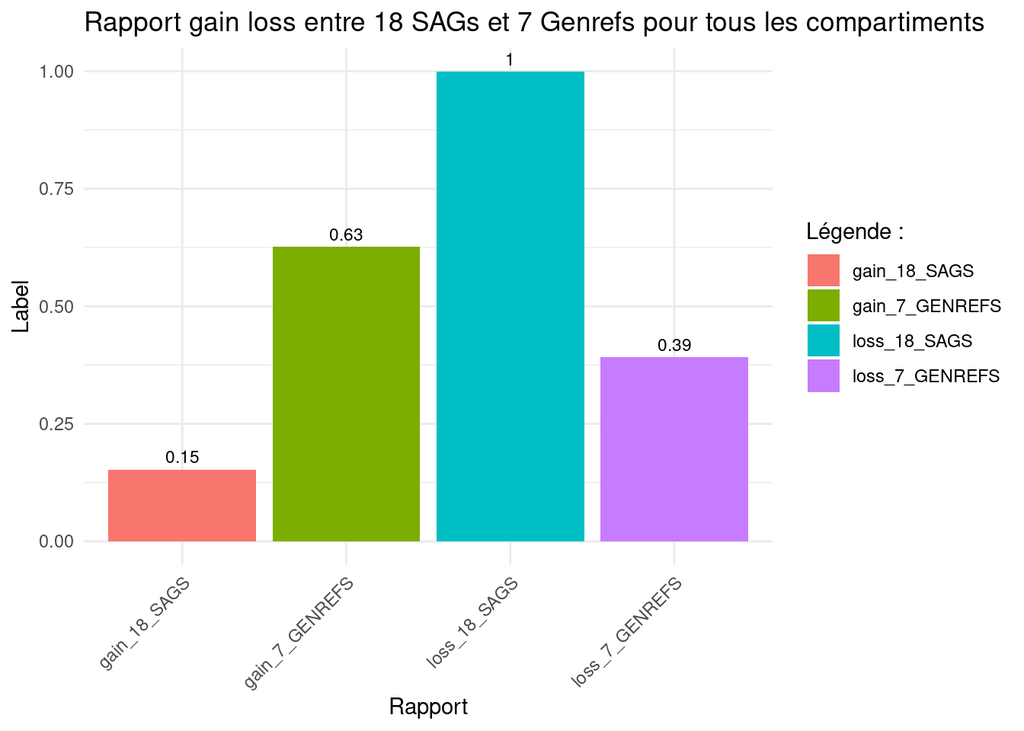

```r
allcomp=melt(rapport_gain_loss_allcompart)
allcomp=allcomp[,c(2,3)]
allcomp[,1]=c("gain_18_SAGS","gain_7_GENREFS","loss_18_SAGS","loss_7_GENREFS")

backbone=melt(rapport_gain_loss_backbone)
backbone=backbone[,c(2,3)]
backbone[,1]=c("gain_18_SAGS","gain_7_GENREFS","loss_18_SAGS","loss_7_GENREFS")

ISLS=melt(rapport_gain_loss_ISLS)
ISLS=ISLS[,c(2,3)]
ISLS[,1]=c("gain_18_SAGS","gain_7_GENREFS","loss_18_SAGS","loss_7_GENREFS")


ggplot(allcomp, aes(x = Var2, y = value, fill= Var2)) +
  geom_bar(stat = "identity") +
  xlab("Rapport") +
  ylab("Label") +
  ggtitle("Rapport gain loss entre 18 SAGs et 7 Genrefs pour tous les compartiments") +
  theme_minimal()+
  theme(axis.text.x = element_text(angle = 45, hjust = 1))+
  geom_text(aes(label = round(value, 2)), vjust = -0.5, size=3) + labs(fill="Légende :")
```

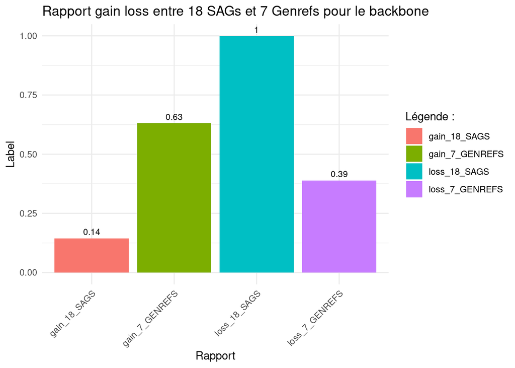

```r
ggplot(backbone, aes(x = Var2, y = value, fill= Var2)) +
  geom_bar(stat = "identity") +
  xlab("Rapport") +
  ylab("Label") +
  ggtitle("Rapport gain loss entre 18 SAGs et 7 Genrefs pour le backbone") +
  theme_minimal()+
  theme(axis.text.x = element_text(angle = 45, hjust = 1))+
  geom_text(aes(label = round(value, 2)), vjust = -0.5, size=3) + labs(fill="Légende :")
```

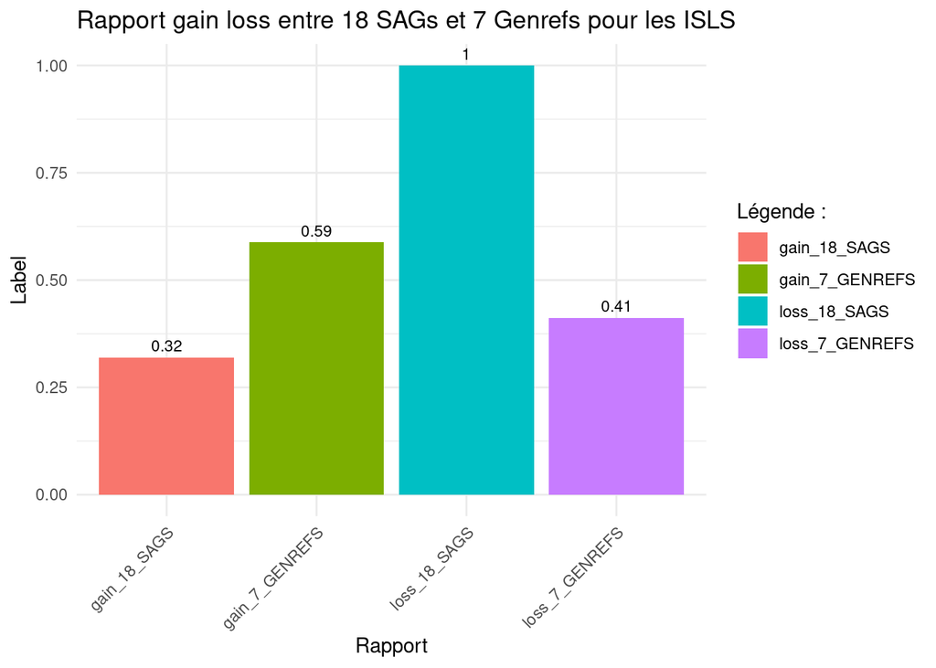

```r
ggplot(ISLS, aes(x = Var2, y = value, fill= Var2)) +
  geom_bar(stat = "identity") +
  xlab("Rapport") +
  ylab("Label") +
  ggtitle("Rapport gain loss entre 18 SAGs et 7 Genrefs pour les ISLS") +
  theme_minimal()+
  theme(axis.text.x = element_text(angle = 45, hjust = 1))+
  geom_text(aes(label = round(value, 2)), vjust = -0.5, size=3) + labs(fill="Légende :")
```

# Partie 7 : Comparaison des COGS with gains (16 vs 10 vs 12)

## Données

```r
COGS_18=data_merge_spec_18$COG[data_merge_spec_18$gentype=="core" & data_merge_spec_18$compartiment %in% c("ISL1", "ISL2", "ISL3", "ISL4", "ISL5") & data_merge_spec_18$Gains>=1]

COGS_7=data_merge_spec_7$COG[data_merge_spec_7$gentype=="core" & data_merge_spec_7$compartiment %in% c("ISL1", "ISL2", "ISL3", "ISL4", "ISL5") & data_merge_spec_7$Gains>=1]

COGS_25=data_merge_spec_25$COG[data_merge_spec_25$gentype=="core" & data_merge_spec_25$compartiment %in% c("ISL1", "ISL2", "ISL3", "ISL4", "ISL5") & data_merge_spec_25$Gains>=1]
```

## Données

```r
COGS_18=as.data.frame(COGS_18)
colnames(COGS_18)="COG"
COGS_18=merge(COGS_18,data_merge_spec_18,by="COG")

COGS_7=as.data.frame(COGS_7)
colnames(COGS_7)="COG"
COGS_7=merge(COGS_7,data_merge_spec_7,by="COG")

COGS_25=as.data.frame(COGS_25)
colnames(COGS_25)="COG"
COGS_25=merge(COGS_25,data_merge_spec_25,by="COG")
```

# Partie 8 : Courbe de flex en fonction de la complétude

## Importation des données

```r
tree <- read.tree("/home/maarque/Donnees_projet/Data/ALL_SAGS_genrefs/REROOT_RAxML_bestTree.ALL_concatenated_cogs.nwk")
pa <- read_rtab("/home/maarque/Donnees_projet/Data/ALL_SAGS_genrefs/Matrice_fusionnee.tsv")
```

```r
fit <- panstripe(pa, tree, family="quasipoisson")

tsv_completion=read.csv("/home/maarque/Donnees_projet/Data/SAGs_reduits/Completion_SAGs.tsv", sep="\t", check.names = FALSE, header=FALSE)
tsv_completion=tsv_completion[,c(1,4)]

#J'enlève MIT9312
tsv_completion=tsv_completion[-88,]


# J'ajoute les autres genrefs
genrefs=data.frame(V1=c("P9312","MIT9215","AS9601","MIT9202","MIT9301"),V4=c("100","100","100","100","100"))
tsv_completion=rbind(tsv_completion,genrefs)

data_compartiments=read.csv("/home/maarque/Donnees_projet/Data/Data_GARDON/Annotation_COGs/All_COGS_max.tsv", header=F, sep="\t", check.names = F)
colnames(data_compartiments)=c("COG","multi/single","gentype","shared","compartiment")
```

## Récupération des noms des COGS présents par SAGS

```r
liste_SAG_COGs <- list()

for (i in 1:nrow(pa)) {
  SAG=rownames(pa)[i]
  indices=which(pa[i, ] == 1)
  COGs=colnames(pa)[indices]
  liste_SAG_COGs[[SAG]]=COGs
}

# Supprimer le SAG "P9312" de la liste des COGs
liste_SAG_COGs=subset(liste_SAG_COGs, !(names(liste_SAG_COGs) %in% c("MED4","MIT9515","NATL1A","NATL2A","MIT0915","MIT1013","MIT1214","MIT0917","MIT0912","MIT0913","SS120","MIT9211","MIT0919","MIT0918","MIT9303","MIT9313")))
```

## Liste des COGS flex

```r
COG_flex=data_compartiments$COG[data_compartiments$gentype=="flex"]

for (SAG in names(liste_SAG_COGs)) {
  COGs=liste_SAG_COGs[[SAG]]
  COGs=COGs[COGs %in% COG_flex]
  liste_SAG_COGs[[SAG]]=COGs
}
```

## Création d’un df qui contient le nombre de COGS flex par SAGS

```r
# Obtenir le nombre de COGs pour chaque SAG
nombre_COGs=sapply(liste_SAG_COGs, length)

# Créer le dataframe avec le nom du SAG et le nombre de COGs
df=data.frame(SAG = names(liste_SAG_COGs), Nombre_COGs = nombre_COGs, stringsAsFactors = FALSE)
```

## Fusion de df pour avoir le nombre de core en fonction de la complétion

```r
colnames(tsv_completion)=c("SAG","completion")
merged_df=merge(df,tsv_completion, by="SAG")
merged_df$completion=sub(",",".",merged_df$completion)
merged_df$completion=as.double(merged_df$completion)
```

## Plot

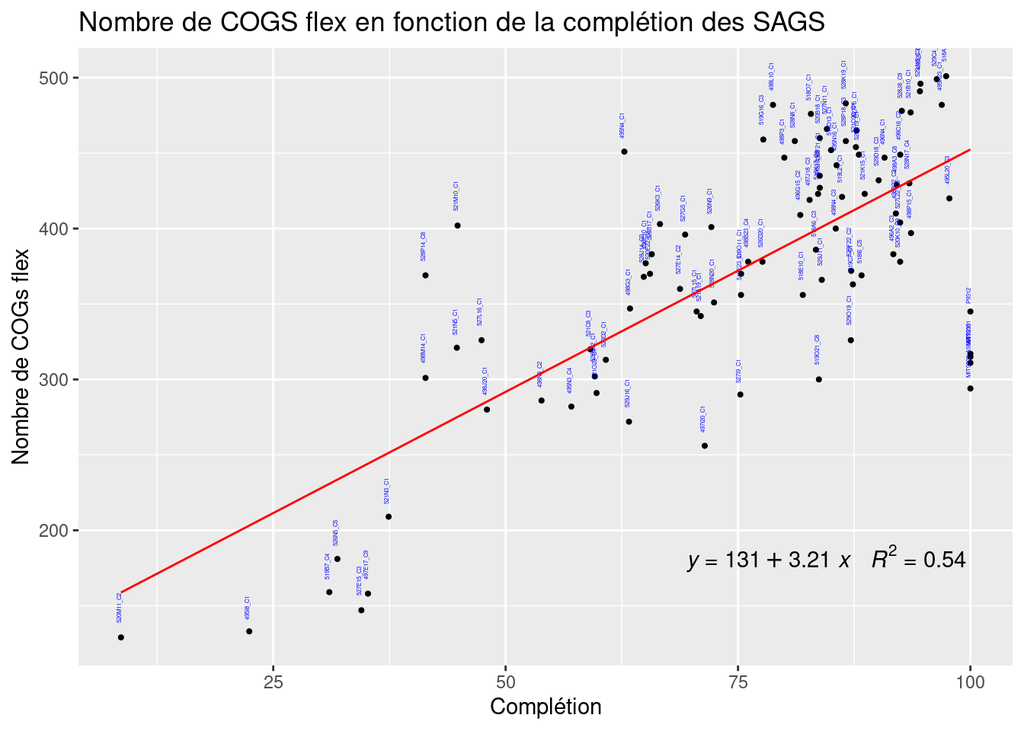

```r
#En affichant le nom des points
ggplot(merged_df, aes(x = completion, y = Nombre_COGs, label = SAG)) +
  geom_point(size = 0.75) +
  geom_text(size = 1, angle = 90, hjust = -0.5, vjust = 0, color = "blue") +
  labs(x = "Complétion", y = "Nombre de COGs flex") +
  ggtitle("Nombre de COGS flex en fonction de la complétion des SAGS") +
  geom_smooth(method = "lm", se = FALSE, color="red", size=0.5) +
  stat_poly_eq(formula = y ~ x, parse = TRUE, aes(label = paste(..eq.label.., ..rr.label.., sep = "~~~")),
               label.x.npc = "right", label.y.npc = 0.15) +
  stat_fit_glance(method = "lm", geom = "text", aes(label = paste("R2 = ", round(..r.squared.., digits = 3))),
                  x.position = "right", y.position = "top")
```

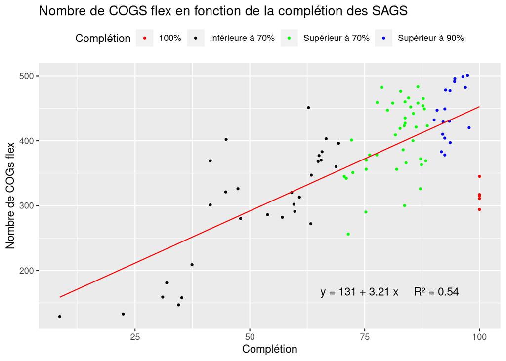

```r
#Sans afficher le nom des points
ggplot(merged_df, aes(x = completion, y = Nombre_COGs, label = SAG, color = ifelse(merged_df$completion == 100, "100%", ifelse(merged_df$completion > 90, "Supérieur à 90%",ifelse(merged_df$completion > 70, "Supérieur à 70%","Inférieure à 70%"))))) +
  geom_point(size = 0.75) +
  labs(x = "Complétion", y = "Nombre de COGs flex") +
  ggtitle("Nombre de COGS flex en fonction de la complétion des SAGS") +
  geom_smooth(method = "lm", se = FALSE, color = "red", size = 0.5) +
  annotate("text", x = Inf, y = -Inf, label = paste("y = 131 + 3.21 x     R² =", round(summary(lm(Nombre_COGs ~ completion, data = merged_df))$r.squared, digits = 2)),
           hjust = 1.3, vjust = -4, color = "black") +
  scale_color_manual(values = c("100%" = "red","Supérieur à 90%" = "blue", "Supérieur à 70%" = "green", "Inférieure à 70%" = "black"),
                     name = "Complétion") +
  theme(legend.position = "top")
```

# Partie 9 : Courbe de core en fonction de la complétude

## Importation des données

```r
tree <- read.tree("/home/maarque/Donnees_projet/Data/ALL_SAGS_genrefs/REROOT_RAxML_bestTree.ALL_concatenated_cogs.nwk")
pa <- read_rtab("/home/maarque/Donnees_projet/Data/ALL_SAGS_genrefs/Matrice_fusionnee.tsv")
```

```r
fit <- panstripe(pa, tree, family="quasipoisson")

tsv_completion=read.csv("/home/maarque/Donnees_projet/Data/SAGs_reduits/Completion_SAGs.tsv", sep="\t", check.names = FALSE, header=FALSE)
tsv_completion=tsv_completion[,c(1,4)]

#J'enlève MIT9312
tsv_completion=tsv_completion[-88,]


# J'ajoute les autres genrefs
genrefs=data.frame(V1=c("P9312","MIT9215","AS9601","MIT9202","MIT9301"),V4=c("100","100","100","100","100"))
tsv_completion=rbind(tsv_completion,genrefs)

data_compartiments=read.csv("/home/maarque/Donnees_projet/Data/Data_GARDON/Annotation_COGs/All_COGS_max.tsv", header=F, sep="\t", check.names = F)
colnames(data_compartiments)=c("COG","multi/single","gentype","shared","compartiment")
```

## Récupération des noms des COGS présents par SAGS

```r
liste_SAG_COGs <- list()

for (i in 1:nrow(pa)) {
  SAG=rownames(pa)[i]
  indices=which(pa[i, ] == 1)
  COGs=colnames(pa)[indices]
  liste_SAG_COGs[[SAG]]=COGs
}

# Supprimer
liste_SAG_COGs=subset(liste_SAG_COGs, !(names(liste_SAG_COGs) %in% c("MED4","MIT9515","NATL1A","NATL2A","MIT0915","MIT1013","MIT1214","MIT0917","MIT0912","MIT0913","SS120","MIT9211","MIT0919","MIT0918","MIT9303","MIT9313")))
```

## Liste des COGS core

```r
COG_flex=data_compartiments$COG[data_compartiments$gentype=="core"]

for (SAG in names(liste_SAG_COGs)) {
  COGs=liste_SAG_COGs[[SAG]]
  COGs=COGs[COGs %in% COG_flex]
  liste_SAG_COGs[[SAG]]=COGs
}
```

## Création d’un df qui contient le nombre de COGS flex par SAGS

```r
# Obtenir le nombre de COGs pour chaque SAG
nombre_COGs=sapply(liste_SAG_COGs, length)

# Créer le dataframe avec le nom du SAG et le nombre de COGs
df=data.frame(SAG = names(liste_SAG_COGs), Nombre_COGs = nombre_COGs, stringsAsFactors = FALSE)
```

## Fusion de df pour avoir le nombre de core en fonction de la complétion

```r
colnames(tsv_completion)=c("SAG","completion")
merged_df=merge(df,tsv_completion, by="SAG")
merged_df$completion=sub(",",".",merged_df$completion)
merged_df$completion=as.double(merged_df$completion)
```

## Plot

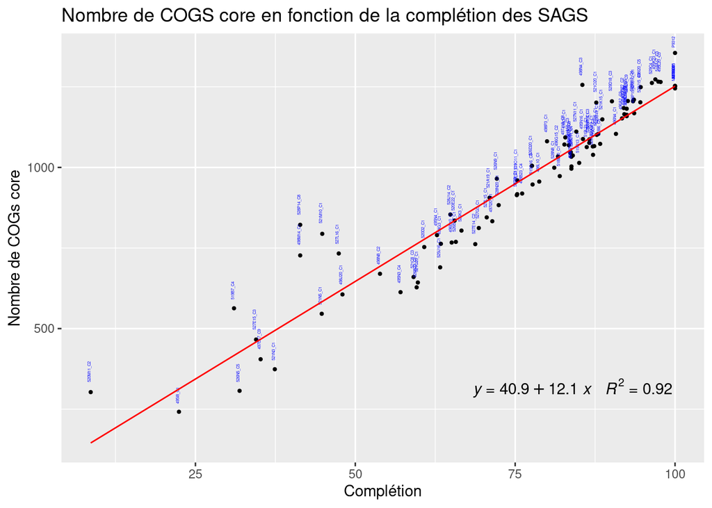

```r
#En affichant le nom des points
ggplot(merged_df, aes(x = completion, y = Nombre_COGs, label = SAG)) +
  geom_point(size = 0.75) +
  geom_text(size = 1, angle = 90, hjust = -0.5, vjust = 0, color = "blue") +
  labs(x = "Complétion", y = "Nombre de COGs core") +
  ggtitle("Nombre de COGS core en fonction de la complétion des SAGS") +
  geom_smooth(method = "lm", se = FALSE, color="red", size=0.5) +
  stat_poly_eq(formula = y ~ x, parse = TRUE, aes(label = paste(..eq.label.., ..rr.label.., sep = "~~~")),
               label.x.npc = "right", label.y.npc = 0.15) +
  stat_fit_glance(method = "lm", geom = "text", aes(label = paste("R2 = ", round(..r.squared.., digits = 3))),
                  x.position = "right", y.position = "top")
```

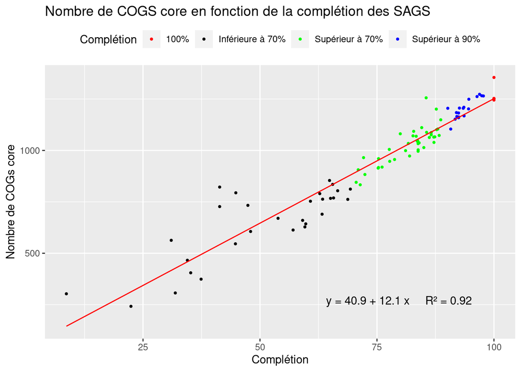

```r
#Sans afficher le nom des points
ggplot(merged_df, aes(x = completion, y = Nombre_COGs, label = SAG, color = ifelse(merged_df$completion == 100, "100%", ifelse(merged_df$completion > 90, "Supérieur à 90%",ifelse(merged_df$completion > 70, "Supérieur à 70%","Inférieure à 70%"))))) +
  geom_point(size = 0.75) +
  labs(x = "Complétion", y = "Nombre de COGs core") +
  ggtitle("Nombre de COGS core en fonction de la complétion des SAGS") +
  geom_smooth(method = "lm", se = FALSE, color = "red", size = 0.5) +
  annotate("text", x = Inf, y = -Inf, label = paste("y = 40.9 + 12.1 x     R² =", round(summary(lm(Nombre_COGs ~ completion, data = merged_df))$r.squared, digits = 2)),
           hjust = 1.3, vjust = -4, color = "black") +
  scale_color_manual(values = c("100%" = "red","Supérieur à 90%" = "blue", "Supérieur à 70%" = "green", "Inférieure à 70%" = "black"),
                     name = "Complétion") +
  theme(legend.position = "top")
```

# Partie 10 : Courbe de flex en fonction de la complétude avec tous les flexs

## Importation des données

```r
tree <- read.tree("/home/maarque/Donnees_projet/Data/ALL_SAGS_genrefs/REROOT_RAxML_bestTree.ALL_concatenated_cogs.nwk")
pa <- read_rtab("/home/maarque/Donnees_projet/Data/ALL_SAGS_genrefs/Matrice_fusionnee.tsv")
```

```r
fit <- panstripe(pa, tree, family="quasipoisson")

tsv_completion=read.csv("/home/maarque/Donnees_projet/Data/SAGs_reduits/Completion_SAGs.tsv", sep="\t", check.names = FALSE, header=FALSE)
tsv_completion=tsv_completion[,c(1,4)]

#J'enlève MIT9312
tsv_completion=tsv_completion[-88,]


# J'ajoute les autres genrefs
genrefs=data.frame(V1=c("P9312","MIT9215","AS9601","MIT9202","MIT9301"),V4=c("100","100","100","100","100"))
tsv_completion=rbind(tsv_completion,genrefs)

data_compartiments=read.csv("/home/maarque/Donnees_projet/Data/ALL_SAGS_genrefs/Annot_All_COGS.tsv", header=F, sep="\t", check.names = F)
colnames(data_compartiments)=c("COG","multi/single","gentype","shared","compartiment")
```

## Récupération des noms des COGS présents par SAGS

```r
liste_SAG_COGs <- list()

for (i in 1:nrow(pa)) {
  SAG=rownames(pa)[i]
  indices=which(pa[i, ] == 1)
  COGs=colnames(pa)[indices]
  liste_SAG_COGs[[SAG]]=COGs
}

# Supprimer le SAG "P9312" de la liste des COGs
liste_SAG_COGs=subset(liste_SAG_COGs, !(names(liste_SAG_COGs) %in% c("MED4","MIT9515","NATL1A","NATL2A","MIT0915","MIT1013","MIT1214","MIT0917","MIT0912","MIT0913","SS120","MIT9211","MIT0919","MIT0918","MIT9303","MIT9313")))
```

## Liste des COGS flex

```r
COG_flex=data_compartiments$COG[data_compartiments$gentype=="flex"]

for (SAG in names(liste_SAG_COGs)) {
  COGs=liste_SAG_COGs[[SAG]]
  COGs=COGs[COGs %in% COG_flex]
  liste_SAG_COGs[[SAG]]=COGs
}
```

## Création d’un df qui contient le nombre de COGS flex par SAGS

```r
# Obtenir le nombre de COGs pour chaque SAG
nombre_COGs=sapply(liste_SAG_COGs, length)

# Créer le dataframe avec le nom du SAG et le nombre de COGs
df=data.frame(SAG = names(liste_SAG_COGs), Nombre_COGs = nombre_COGs, stringsAsFactors = FALSE)
```

## Fusion de df pour avoir le nombre de core en fonction de la complétion

```r
colnames(tsv_completion)=c("SAG","completion")
merged_df=merge(df,tsv_completion, by="SAG")
merged_df$completion=sub(",",".",merged_df$completion)
merged_df$completion=as.double(merged_df$completion)
```

## Plot

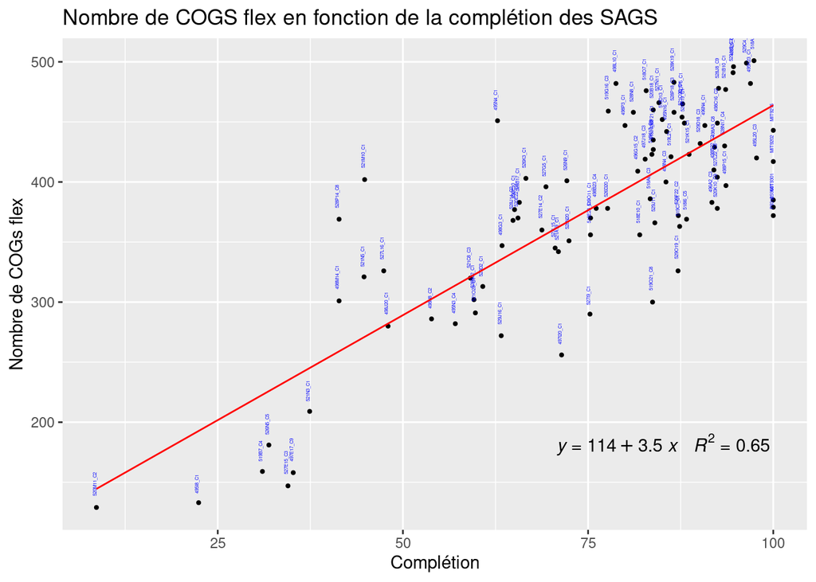

```r
#En affichant le nom des points
ggplot(merged_df, aes(x = completion, y = Nombre_COGs, label = SAG)) +
  geom_point(size = 0.75) +
  geom_text(size = 1, angle = 90, hjust = -0.5, vjust = 0, color = "blue") +
  labs(x = "Complétion", y = "Nombre de COGs flex") +
  ggtitle("Nombre de COGS flex en fonction de la complétion des SAGS") +
  geom_smooth(method = "lm", se = FALSE, color="red", size=0.5) +
  stat_poly_eq(formula = y ~ x, parse = TRUE, aes(label = paste(..eq.label.., ..rr.label.., sep = "~~~")),
               label.x.npc = "right", label.y.npc = 0.15) +
  stat_fit_glance(method = "lm", geom = "text", aes(label = paste("R2 = ", round(..r.squared.., digits = 3))),
                  x.position = "right", y.position = "top")
```

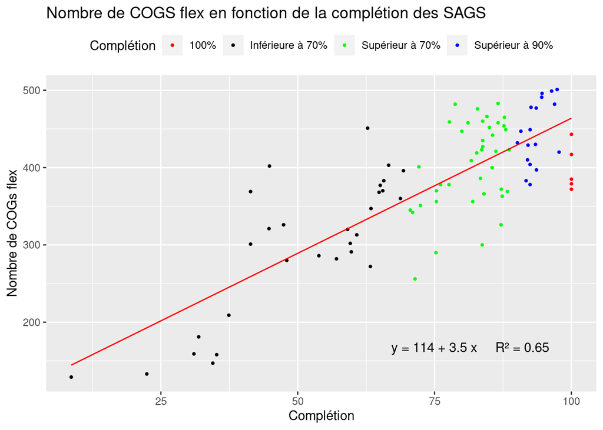

```r
#Sans afficher le nom des points
ggplot(merged_df, aes(x = completion, y = Nombre_COGs, label = SAG, color = ifelse(merged_df$completion == 100, "100%", ifelse(merged_df$completion > 90, "Supérieur à 90%",ifelse(merged_df$completion > 70, "Supérieur à 70%","Inférieure à 70%"))))) +
  geom_point(size = 0.75) +
  labs(x = "Complétion", y = "Nombre de COGs flex") +
  ggtitle("Nombre de COGS flex en fonction de la complétion des SAGS") +
  geom_smooth(method = "lm", se = FALSE, color = "red", size = 0.5) +
  annotate("text", x = Inf, y = -Inf, label = paste("y = 114 + 3.5 x     R² =", round(summary(lm(Nombre_COGs ~ completion, data = merged_df))$r.squared, digits = 2)),
           hjust = 1.3, vjust = -4, color = "black") +
  scale_color_manual(values = c("100%" = "red","Supérieur à 90%" = "blue", "Supérieur à 70%" = "green", "Inférieure à 70%" = "black"),
                     name = "Complétion") +
  theme(legend.position = "top")
```

# Partie 11 : Autres tests statistiques

## Pour I/NI en fonction du core et flex de 18 vs 7

#### Question : Y’a-t-il une association significative entre les I/NI du core et flex des 18 SAGS vs 7 genrefs : non

```r
data=matrix(c(3392,614,228,1338), nrow = 2, ncol = 2, dimnames = list(c("18", "7"), c("Impacted", "Not_Impacted")))
data3=fisher.test(data)
print(data3)
```

```
##
##  Fisher's Exact Test for Count Data
##
## data:  data
## p-value < 2.2e-16
## alternative hypothesis: true odds ratio is not equal to 1
## 95 percent confidence interval:
##  27.43459 38.37312
## sample estimates:
## odds ratio
##   32.38792
```

```r
print(data3$p.value)
```

```
## [1] 0
```

## Pour I/NI en fonction du core de 18 vs 7

#### Question : Y’a-t-il une association significative entre les I/NI du core des 18 SAGS vs 7 genrefs : non

```r
data=matrix(c(1141,166,214,1189), nrow = 2, ncol = 2, dimnames = list(c("18", "7"), c("Impacted", "Not_Impacted")))
data4=fisher.test(data)
print(data4)
```

```
##
##  Fisher's Exact Test for Count Data
##
## data:  data
## p-value < 2.2e-16
## alternative hypothesis: true odds ratio is not equal to 1
## 95 percent confidence interval:
##  30.52334 47.81770
## sample estimates:
## odds ratio
##   38.09568
```

```r
print(data4$p.value)
```

```
## [1] 0
```

## Pour gain no gain en fonction du core de 18 vs 7

#### Question : Y’a-t-il une association significative entre les rapports gains/nogains du core des 18 SAGS vs 7 genrefs : non

```r
data=matrix(c(174,104,1181,62), nrow = 2, ncol = 2, dimnames = list(c("18", "7"), c("Gains", "Not_Gains")))
data=fisher.test(data)
print(data)
```

```
##
##  Fisher's Exact Test for Count Data
##
## data:  data
## p-value < 2.2e-16
## alternative hypothesis: true odds ratio is not equal to 1
## 95 percent confidence interval:
##  0.06074527 0.12684021
## sample estimates:
## odds ratio
## 0.08805239
```

```r
print(data$p.value)
```

```
## [1] 1.045592e-42
```

## Pour loss no loss en fonction du core de 18 vs 7

#### Question : Y’a-t-il une association significative entre les rapports loss/noloss du core des 18 SAGS vs 7 genrefs : non

```r
data=matrix(c(1140,65,1,101), nrow = 2, ncol = 2, dimnames = list(c("18", "7"), c("Loss", "Not_Loss")))
data2=fisher.test(data)
print(data2)
```

```
##
##  Fisher's Exact Test for Count Data
##
## data:  data
## p-value < 2.2e-16
## alternative hypothesis: true odds ratio is not equal to 1
## 95 percent confidence interval:
##  2.946735e+02 4.503600e+15
## sample estimates:
## odds ratio
##   1728.542
```

```r
print(data2$p.value)
```

```
## [1] 1.004182e-104
```

## Pour loss/non loss en fonction de compartiment et gentype : gentype7

#### Question : Y’a-t-il une association significative entre les loss/noloss du core/flex des 7 genrefs : non

```r
mat_gentype7_gain=matrix(c(65,107,101,341), nrow = 2, ncol = 2, dimnames = list(c("Core", "Flex"), c("Loss", "Not_Loss")))
gentype7_gain=fisher.test(mat_gentype7_gain)
print(gentype7_gain)
```

```
##
##  Fisher's Exact Test for Count Data
##
## data:  mat_gentype7_gain
## p-value = 0.0002591
## alternative hypothesis: true odds ratio is not equal to 1
## 95 percent confidence interval:
##  1.374450 3.047209
## sample estimates:
## odds ratio
##   2.048409
```

```r
print(gentype7_gain$p.value)
```

```
## [1] 0.0002591163
```

## Pour loss/non loss en fonction de compartiment et gentype : compart7 pour core

#### Question : Y’a-t-il une association significative entre les rapports loss/noloss des compartiments du core des 7 genrefs : oui

```r
mat_compart7_core_gain=matrix(c(58,7,91,10), nrow = 2, ncol = 2, dimnames = list(c("backbone", "ISLs"), c("Loss", "Not_Loss")))
compart7_core_gain=fisher.test(mat_compart7_core_gain)
print(compart7_core_gain)
```

```
##
##  Fisher's Exact Test for Count Data
##
## data:  mat_compart7_core_gain
## p-value = 1
## alternative hypothesis: true odds ratio is not equal to 1
## 95 percent confidence interval:
##  0.2938026 2.9890896
## sample estimates:
## odds ratio
##  0.9110377
```

```r
print(compart7_core_gain$p.value)
```

```
## [1] 1
```

# Partie 12 : Gain/no gain sur la totalité et pas seulement les impactés

## Pour gains/non gains en fonction de compartiment et gentype : gentype18

#### Question : Y’a-t-il une association significative entre les gain/no gain du core et flex des 18 SAGS : non

```r
mat_gentype18_gain=matrix(c(174,2067,1181,198), nrow = 2, ncol = 2, dimnames = list(c("Core", "Flex"), c("Gains", "Not_Gains")))
gentype18_gain=fisher.test(mat_gentype18_gain)
print(gentype18_gain)
```

```
##
##  Fisher's Exact Test for Count Data
##
## data:  mat_gentype18_gain
## p-value < 2.2e-16
## alternative hypothesis: true odds ratio is not equal to 1
## 95 percent confidence interval:
##  0.01127969 0.01764304
## sample estimates:
## odds ratio
## 0.01417604
```

```r
print(gentype18_gain$p.value)
```

```
## [1] 0
```

## Pour gains/non gains en fonction de compartiment et gentype : gentype7

#### Question : Y’a-t-il une association significative entre les gain/no gain du core et flex des 7 genrefs : non

```r
mat_gentype7_gain=matrix(c(104,349,1251,946), nrow = 2, ncol = 2, dimnames = list(c("Core", "Flex"), c("Gains", "Not_Gains")))
gentype7_gain=fisher.test(mat_gentype7_gain)
print(gentype7_gain)
```

```
##
##  Fisher's Exact Test for Count Data
##
## data:  mat_gentype7_gain
## p-value < 2.2e-16
## alternative hypothesis: true odds ratio is not equal to 1
## 95 percent confidence interval:
##  0.1764789 0.2862149
## sample estimates:
## odds ratio
##   0.225468
```

```r
print(gentype7_gain$p.value)
```

```
## [1] 4.279126e-41
```

## Pour gains/non gains en fonction de compartiment et gentype : compart18 pour core

#### Question : Y’a-t-il une association significative entre les gain/no gain du core ISLS/backbone des 18 SAGS : non

```r
mat_compart18_core_gain=matrix(c(158,16,1147,34), nrow = 2, ncol = 2, dimnames = list(c("backbone", "ISLs"), c("Gains", "Not_Gains")))
compart18_core_gain=fisher.test(mat_compart18_core_gain)
print(compart18_core_gain)
```

```
##
##  Fisher's Exact Test for Count Data
##
## data:  mat_compart18_core_gain
## p-value = 0.0002605
## alternative hypothesis: true odds ratio is not equal to 1
## 95 percent confidence interval:
##  0.1532883 0.5824585
## sample estimates:
## odds ratio
##  0.2931259
```

```r
print(compart18_core_gain$p.value)
```

```
## [1] 0.0002605106
```

## Pour gains/non gains en fonction de compartiment et gentype : compart7 pour core

#### Question : Y’a-t-il une association significative entre les gain/no gain du core ISLS/backbone des 7 genrefs : non

```r
mat_compart7_core_gain=matrix(c(94,10,1211,40), nrow = 2, ncol = 2, dimnames = list(c("backbone", "ISLs"), c("Gains", "Not_Gains")))
compart7_core_gain=fisher.test(mat_compart7_core_gain)
print(compart7_core_gain)
```

```
##
##  Fisher's Exact Test for Count Data
##
## data:  mat_compart7_core_gain
## p-value = 0.003487
## alternative hypothesis: true odds ratio is not equal to 1
## 95 percent confidence interval:
##  0.1468698 0.7196878
## sample estimates:
## odds ratio
##  0.3109054
```

```r
print(compart7_core_gain$p.value)
```

```
## [1] 0.003487075
```

## Pour gain no gain en fonction du core de 18 vs 7

#### Question : Y’a-t-il une association significative entre les gain/no gain du core entre les 18 SAGS et les 7 genrefs : non

```r
data=matrix(c(174,104,1181,1251), nrow = 2, ncol = 2, dimnames = list(c("18", "7"), c("Gains", "Not_Gains")))
data=fisher.test(data)
print(data)
```

```
##
##  Fisher's Exact Test for Count Data
##
## data:  data
## p-value = 1.144e-05
## alternative hypothesis: true odds ratio is not equal to 1
## 95 percent confidence interval:
##  1.363179 2.311795
## sample estimates:
## odds ratio
##   1.771853
```

```r
print(data$p.value)
```

```
## [1] 1.143913e-05
```

## Pour loss no loss en fonction du core de 18 vs 7

#### Question : Y’a-t-il une association significative entre les loss/non loss du core entre les 18 SAGS et les 7 genrefs : non

```r
data=matrix(c(1140,65,215,1290), nrow = 2, ncol = 2, dimnames = list(c("18", "7"), c("Loss", "Not_Loss")))
data2=fisher.test(data)
print(data2)
```

```
##
##  Fisher's Exact Test for Count Data
##
## data:  data
## p-value < 2.2e-16
## alternative hypothesis: true odds ratio is not equal to 1
## 95 percent confidence interval:
##   78.2475 142.9434
## sample estimates:
## odds ratio
##   104.7747
```

```r
print(data2$p.value)
```

```
## [1] 0
```

## Pour loss/non loss en fonction de compartiment et gentype : gentype7

#### Question : Y’a-t-il une association significative entre les loss/non loss dans le core et flex des 7 genrefs : non

```r
mat_gentype7_gain=matrix(c(65,107,1290,597), nrow = 2, ncol = 2, dimnames = list(c("Core", "Flex"), c("Loss", "Not_Loss")))
gentype7_gain=fisher.test(mat_gentype7_gain)
print(gentype7_gain)
```

```
##
##  Fisher's Exact Test for Count Data
##
## data:  mat_gentype7_gain
## p-value = 7.191e-15
## alternative hypothesis: true odds ratio is not equal to 1
## 95 percent confidence interval:
##  0.2002725 0.3927368
## sample estimates:
## odds ratio
##  0.2813334
```

```r
print(gentype7_gain$p.value)
```

```
## [1] 7.190918e-15
```

## Pour loss/non loss en fonction de compartiment et gentype : compart7 pour core

#### Question : Y’a-t-il une association significative entre les loss/non loss dans le backbone et les ilots pour le core des 7 genrefs : non

```r
mat_compart7_core_gain=matrix(c(58,7,1247,43), nrow = 2, ncol = 2, dimnames = list(c("backbone", "ISLs"), c("Loss", "Not_Loss")))
compart7_core_gain=fisher.test(mat_compart7_core_gain)
print(compart7_core_gain)
```

```
##
##  Fisher's Exact Test for Count Data
##
## data:  mat_compart7_core_gain
## p-value = 0.008165
## alternative hypothesis: true odds ratio is not equal to 1
## 95 percent confidence interval:
##  0.1205284 0.7867466
## sample estimates:
## odds ratio
##  0.2861631
```

```r
print(compart7_core_gain$p.value)
```

```
## [1] 0.008164593
```

## Pour BB/ISLS vs core/flex des impactés : 18

#### Question : Y’a-t-il une association significative entre le backbone et les ilôts pour les génomes core et flex pour les 18 SAGS : non

```r
data=matrix(c(1091,1404,50,847), nrow = 2, ncol = 2, dimnames = list(c("Core", "Flex"), c("backbone", "ISLS")))
data=fisher.test(data)
print(data)
```

```
##
##  Fisher's Exact Test for Count Data
##
## data:  data
## p-value < 2.2e-16
## alternative hypothesis: true odds ratio is not equal to 1
## 95 percent confidence interval:
##   9.765143 18.063939
## sample estimates:
## odds ratio
##   13.15559
```

```r
print(data$p.value)
```

```
## [1] 5.077211e-116
```

## Pour BB/ISLS vs core/flex des impactés : 7

#### Question : Y’a-t-il une association significative entre le backbone et les ilôts pour les génomes core et flex pour les 7 genrefs : non

```r
data=matrix(c(149,179,17,269), nrow = 2, ncol = 2, dimnames = list(c("Core", "Flex"), c("backbone", "ISLS")))
data=fisher.test(data)
print(data)
```

```
##
##  Fisher's Exact Test for Count Data
##
## data:  data
## p-value < 2.2e-16
## alternative hypothesis: true odds ratio is not equal to 1
## 95 percent confidence interval:
##   7.596992 23.965258
## sample estimates:
## odds ratio
##   13.11647
```

```r
print(data$p.value)
```

```
## [1] 5.211644e-31
```